# Homework 2 Solutions

## **Remark 1:**

**This solution uses `gradient_descent()` from the `optimizers` library but you are not expected to learn or use it. Rather, you should write your own `gradient_descent()` (you are allowed to copy it from your previous assignment since we have done it). Since you probably need to call this function multiple times, you may want to create a cell for it at the beginning of your notebook so that you don’t have to copy the same code into several answers. This should be a general coding practice for you to follow in your future assignments too.**

## **Remark 2:**

**As said in the instruction of the problem sets, you do not have to produce the contour plots. On the other hand, for simple 1-D plots (e.g., y vs x, cost function history), you should (and can easily) plot it yourself, typically using `matplotlib.pyplot`. This solution uses `superlearn` but you are not expected to learn or use that library.**

## Problem 1: Implementing the Cross Entropy cost and optimizing the cost (20 points)

```python
from autograd import numpy as np
from autograd import grad
import matplotlib.pyplot as plt
```

```python
data = np.loadtxt("problem1.csv",delimiter=',')

x = data[:-1,:]
y = data[-1:,:]
```

```python
# compute linear combination of input point
def model(x,w):
    a = w[0] + np.dot(x.T,w[1:])
    return a.T

# define sigmoid function
def sigmoid(t):
    return 1/(1 + np.exp(-t))

# the convex cross-entropy cost function
def cross_entropy(w):
    # compute sigmoid of model
    a = sigmoid(model(x,w))

    # compute cost of label 0 points
    ind = np.argwhere(y == 0)[:,1]
    cost = -np.sum(np.log(1 - a[ind]))

    # add cost on label 1 points
    ind = np.argwhere(y==1)[:,1]
    cost -= np.sum(np.log(a[ind]))

    # compute cross-entropy
    return cost/y.size
```

```python
weights = np.array([3.0, 3.0])
weights[1:].shape
```

```
(1,)
```

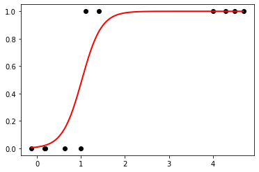

```python
cost_der = grad(cross_entropy)
weights = np.array([3.0, 3.0])
n_iterations = 2000
step_length = 0.1
for i in range(n_iterations):

    der = cost_der(weights)

    weights -= der * step_length

plt.scatter(x, y,color='black')
plot_range = np.arange(np.min(x), np.max(x), 0.01)
plt.plot(plot_range, sigmoid(model(np.array([plot_range]), weights)),color='r',linewidth=2)
plt.show()
```

## Problem 2: Implementing the Softmax cost and optimizing the cost (20 points)

```python
# load in data
csvname = 'problem2.csv'
data = np.loadtxt(csvname,delimiter = ',')

# take input/output pairs from data
x = data[:-1,:]
y = data[-1:,:]
```

```python
# compute linear combination of input point
def model(x,w):
    a = w[0] + np.dot(x.T,w[1:])
    return a.T

# the convex softmax cost function
def softmax(w):
    cost = np.sum(np.log(1 + np.exp(-y*model(x,w))))
    return cost/float(np.size(y))
```

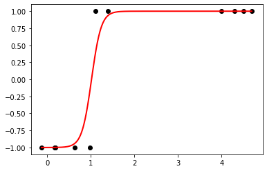

```python
cost_der = grad(softmax)
weights = np.array([3.0, 3.0])
n_iterations = 2000
step_length = 0.1
for i in range(n_iterations):

    der = cost_der(weights)

    weights -= der * step_length

plt.scatter(x, y,color='black')
plot_range = np.arange(np.min(x), np.max(x), 0.01)
plt.plot(plot_range, np.tanh(model(np.array([plot_range]), weights)),color='r',linewidth=2)
plt.show()
```

# Problem 3: Implementing the regularized Softmax and optimizing the loss (15 points)

```python
# load in data
csvname = 'problem2.csv'
data = np.loadtxt(csvname,delimiter = ',')

# take input/output pairs from data
x = data[:-1,:]
y = data[-1:,:]
```

```python
# This code cell will not be shown in the HTML version of this notebook
### define softmax cost ###
# compute linear combination of input point
def model(x,w):
    a = w[0] + np.dot(x.T,w[1:])
    return a.T

# the convex softmax cost function
lam = 1*10**(-3)
def regularized_softmax(w):
    # compute cost value
    cost = np.sum(np.log(1 + np.exp(-y*model(x,w))))

    # add regularizer
    cost += lam*np.sum(w[1:]**2)
    return cost/float(np.size(y))
```

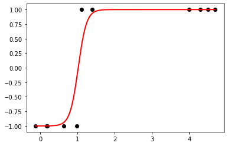

```python
cost_der = grad(regularized_softmax)
weights = np.array([3.0, 3.0])
n_iterations = 2000
step_length = 0.1
for i in range(n_iterations):

    der = cost_der(weights)

    weights -= der * step_length

plt.scatter(x, y,color='black')
plot_range = np.arange(np.min(x), np.max(x), 0.01)
plt.plot(plot_range, np.tanh(model(np.array([plot_range]), weights)),color='r',linewidth=2)
plt.show()
```

## Problem 4: Show the equivalence of the Log Error and Softmax point-wise cost (15 points)

Consider the following cases:

**Case 1.** $y_{p}=+1$

Plugging $y_{p}=+1$ into

$$ \mbox{log}\left(1+e^{-y_p \mathring{\mathbf{x}}_{p}^{T}\mathbf{w}}\right) $$

we have

$$ \mbox{log}\left(1+e^{-y_p \mathring{\mathbf{x}}_{p}^{T}\mathbf{w}}\right) = \mbox{log}\left(1+e^{- \mathring{\mathbf{x}}_{p}^{T}\mathbf{w}}\right) = -\mbox{log}\left(\frac{1}{1+e^{- \mathring{\mathbf{x}}_{p}^{T}\mathbf{w}}}\right)= -\mbox{log}\, \sigma\left(\mathring{\mathbf{x}}_{p}^{T}\mathbf{w}\right) $$

**Case 2.** $y_{p}=-1$

Plugging $y_{p}=-1$ into

$$ \mbox{log}\left(1+e^{-y_p \mathring{\mathbf{x}}_{p}^{T}\mathbf{w}}\right) $$

we have

$$ \mbox{log}\left(1+e^{-y_p \mathring{\mathbf{x}}_{p}^{T}\mathbf{w}}\right) = \mbox{log}\left(1+e^{\mathring{\mathbf{x}}_{p}^{T}\mathbf{w}}\right) = -\mbox{log}\left(\frac{1}{1+e^{ \mathring{\mathbf{x}}_{p}^{T}\mathbf{w}}}\right)= -\mbox{log}\, \sigma\left(-\mathring{\mathbf{x}}_{p}^{T}\mathbf{w}\right) $$

## Problem 5: Implementing the Log Error version of Softmax and optimizing the loss (30 points)

```python
# load in dataset
data = np.loadtxt('problem5.csv',delimiter = ',')

# take input/output pairs from data
x = data[:-1,:]
y = data[-1:,:]
```

```python
print(x.shape)
print(y.shape)
```

```
(2, 100)
(1, 100)
```

```python
# define sigmoid function
def sigmoid(t):
    return 1/(1 + np.exp(-t))

# the convex cross-entropy cost function
def softmax(w):
    # compute sigmoid of model
    a = sigmoid(model(x,w))

    # compute cost of label 0 points
    ind = np.argwhere(y == -1)[:,1]
    cost = -np.sum(np.log(1 - a[ind]))

    # add cost on label 1 points
    ind = np.argwhere(y==+1)[:,1]
    cost -= np.sum(np.log(a[ind]))

    # compute cross-entropy
    return cost/y.size
```

```python
cost_der = grad(softmax)
weights = np.array([3.0, 3.0,3.0])
n_iterations = 2000
step_length = 0.1
for i in range(n_iterations):

    der = cost_der(weights)

    weights -= der * step_length
```

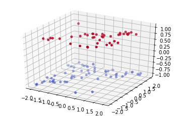

```python
from mpl_toolkits import mplot3d
from matplotlib import cm
from mpl_toolkits.mplot3d.axes3d import get_test_data
fig = plt.figure()
ax = plt.axes(projection='3d')
ax.scatter(x[0,:], x[1,:], y, c=y,cmap=cm.coolwarm, linewidth=0.5);
```

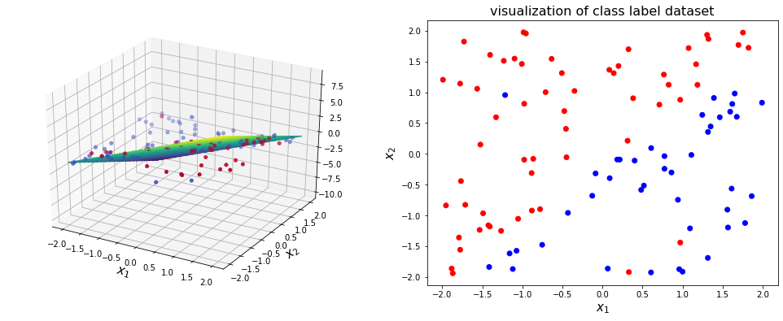

```python
fig = plt.figure(figsize=(17,6))
# =============
# First subplot
# =============
# set up the axes for the first plot
ax = fig.add_subplot(1, 2, 1, projection='3d')

# plot a 3D surface like in the example mplot3d/surface3d_demo
scatter = ax.scatter(x[0,:], x[1,:], y, c=y,cmap=cm.coolwarm, linewidth=0.5);

ax.set_xlabel(r'$x_1$',size=15)
ax.set_ylabel('$x_2$',size=15)

# Data for a three-dimensional line

def f(x, y):
    return weights[0] + weights[1] * x + weights[2] * y

xline = np.linspace(-2,2,2000)
yline = np.linspace(-2,2,2000)

X, Y = np.meshgrid(xline, yline)
Z = f(X,Y)
ax.contour3D(X, Y, Z,50)

#ax.set_zlim(-1.01, 1.01)
#fig.colorbar(scatter, shrink=0.5, aspect=10)

# ==============
# Second subplot
# ==============
# set up the axes for the second plot
ax = fig.add_subplot(1, 2, 2)

def get_color(n):
    if n == 0:
        return 'g'
    elif n == 1:
        return 'b'
    return 'r'

ax.scatter(x[0], x[1],c =[get_color(n) for n in y[0]])

ax.set_xlabel(r'$x_1$',size=15)
ax.set_ylabel('$x_2$',size=15)
ax.set_title("visualization of class label dataset",size=16)
plt.show()
```